# Lab 02

# R Markdown - http://rmarkdown.rstudio.com

# Solucion Laboratorio 2:

Importando libreria

```r
library("ggplot2");
library("readr");
library("dplyr");
library("highcharter");
library("treemap"); # Gráfico treemap
library("modeest"); # Moda estimada
library("GGally");
library("infotheo"); # Discretize variable
library("sqldf"); # SQL para data frames
library("MASS"); # Chi2 en variables cualitativas
```

Leer CSV’s

```r
sn <- read.csv("C:\\Users\\Lucas\\Desktop\\2019\\Data minning\\DataMiningUba2020\\Tps\\Lab02\\MPI_subnational.csv")
n <- read.csv("C:\\Users\\Lucas\\Desktop\\2019\\Data minning\\DataMiningUba2020\\Tps\\Lab02\\MPI_national.csv")
```

## Primera impresión de ambos dataset

Subnational

```r
str(sn)
```

```
'data.frame':   984 obs. of  8 variables:
 $ ISO.country.code                 : chr  "AFG" "AFG" "AFG" "AFG" ...
 $ Country                          : chr  "Afghanistan" "Afghanistan" "Afghanistan" "Afghanistan" ...
 $ Sub.national.region              : chr  "Badakhshan" "Badghis" "Baghlan" "Balkh" ...
 $ World.region                     : chr  "South Asia" "South Asia" "South Asia" "South Asia" ...
 $ MPI.National                     : num  0.295 0.295 0.295 0.295 0.295 0.295 0.295 0.295 0.295 0.295 ...
 $ MPI.Regional                     : num  0.387 0.466 0.3 0.301 0.325 0.313 0.319 0.25 0.245 0.384 ...
 $ Headcount.Ratio.Regional         : num  67.5 79.3 59.7 55.7 61 65.1 61.4 49.4 47.4 74.6 ...
 $ Intensity.of.deprivation.Regional: num  57.3 58.8 50.3 54.1 53.3 48.1 52 50.6 51.6 51.5 ...
```

National

```r
str(n)
```

```
'data.frame':   102 obs. of  8 variables:
 $ ISO                           : chr  "KAZ" "SRB" "KGZ" "TUN" ...
 $ Country                       : chr  "Kazakhstan" "Serbia" "Kyrgyzstan" "Tunisia" ...
 $ MPI.Urban                     : num  0 0 0 0 0.001 0.001 0.001 0.001 0.001 0.002 ...
 $ Headcount.Ratio.Urban         : num  0 0.1 0.1 0.1 0.2 0.3 0.4 0.3 0.4 0.4 ...
 $ Intensity.of.Deprivation.Urban: num  33.3 41.4 40.2 35.6 33.3 36.3 33.9 42.2 38.2 47.2 ...
 $ MPI.Rural                     : num  0 0.002 0.003 0.012 0.001 0.004 0.001 0.003 0.017 0 ...
 $ Headcount.Ratio.Rural         : num  0.09 0.5 0.7 3.18 0.39 1.17 0.32 1.01 4.25 0.09 ...
 $ Intensity.of.Deprivation.Rural: num  33.3 40.3 37.1 38.7 36.9 35.5 34.3 34.7 40.4 41.1 ...
```

### Primeras observaciones

- Disparidad en la cantidad de registros.
- Columnas coincidentes: ISO - ISO.country.code, Country - Country
- Subnational muestra la información de cada provincia de una forma general.
- National muestra para cada pais información de pobreza en area rural y urbana.
- Continua habiendo un solo dato nulo.

### Paises en ambos datasets

- Hay diferencias en los países de ambos datasets. MPI national tiene 102 países y MPI subnational tiene 78.

```r
# Cantidad de países únicos.
# length(unique(n$Country))
# length(unique(sn$Country))
# Nombre de los países que no están en ambos datasets.
setdiff(unique(n$Country), unique(sn$Country))
```

```
 [1] "Kazakhstan"                                 "Serbia"
 [3] "Kyrgyzstan"                                 "Tunisia"
 [5] "Armenia"                                    "Macedonia, The former Yugoslav Republic of"
 [7] "Turkmenistan"                               "Moldova, Republic of"
 [9] "Montenegro"                                 "Saint Lucia"
[11] "Mexico"                                     "Thailand"
[13] "Bosnia and Herzegovina"                     "Algeria"
[15] "Albania"                                    "Ukraine"
[17] "Barbados"                                   "Palestine, State ofa"
[19] "Maldives"                                   "Azerbaijan"
[21] "South Africa"                               "Vanuatu"
[23] "India"                                      "Somalia"
```

### Merge (…y primeras correciones)

¿Cual sería la mejor estrategia?

- Donde ambos coinciden
- A partir de uno de los dos dataset, descartando valores

La idea es unir ambos datasets a partir del paises, en el caso donde ambos están. Esto da mayor información para cada registro del dataset subnational, con el costo de descartar algunos países.

```r
df <- merge(n, sn, by.x = "ISO",  by.y = "ISO.country.code")
# Correcciones
df$Country.y <- NULL
names(df)[2] = "Country"
```

? Usar el merge para validar datos. * Por ejemplo, casos donde el promedio del país está a mas de 3 desviaciones estándares del mpi nacional? * Variables donde colocar granularidad?

### Otras transformaciones

A modo de simplificar el trabajo y los gráficos, opté por armar un grafico más simple. Reduciendo el nombre las columnas a una expresión más corta, y borrando la columna ISO que no aporta valor (Ya que el dato está contenido dentro de país).

Adicionalmente agregar dos variables: * num_simple <- Representa las columnas numéricas del dataframe. * no_na_df_simple <- Que es la versión del dataframe sin valores indefinidos.

```r
df_simple <- df
df_simple$ISO <- NULL
names(df_simple) <- c(
  "Country"
  , "Urban"
  , "R.Urban"
  , "IOD.Urban"
  , "Rural"
  , "R.Rural"
  , "IOD.Rural"
  , "Region"
  , "World.region"
  , "National"
  , "Regional"
  , "R.Regional"
  , "IOD.Regional")
str(df_simple)
```

```
'data.frame':   984 obs. of  13 variables:
 $ Country     : chr  "Afghanistan" "Afghanistan" "Afghanistan" "Afghanistan" ...
 $ Urban       : num  0.132 0.132 0.132 0.132 0.132 0.132 0.132 0.132 0.132 0.132 ...
 $ R.Urban     : num  28.8 28.8 28.8 28.8 28.8 28.8 28.8 28.8 28.8 28.8 ...
 $ IOD.Urban   : num  45.8 45.8 45.8 45.8 45.8 45.8 45.8 45.8 45.8 45.8 ...
 $ Rural       : num  0.347 0.347 0.347 0.347 0.347 0.347 0.347 0.347 0.347 0.347 ...
 $ R.Rural     : num  64.7 64.7 64.7 64.7 64.7 ...
 $ IOD.Rural   : num  53.6 53.6 53.6 53.6 53.6 53.6 53.6 53.6 53.6 53.6 ...
 $ Region      : chr  "Kunarha" "Kabul" "Nangarhar" "Kapisa" ...
 $ World.region: chr  "South Asia" "South Asia" "South Asia" "South Asia" ...
 $ National    : num  0.295 0.295 0.295 0.295 0.295 0.295 0.295 0.295 0.295 0.295 ...
 $ Regional    : num  0.269 0.117 0.287 0.28 0.294 0.437 0.261 0.369 0.296 0.293 ...
 $ R.Regional  : num  58.3 25.3 54.9 53.6 60.5 72.1 61.8 70.4 57.8 60.9 ...
 $ IOD.Regional: num  46.2 46.1 52.4 52.3 48.5 60.7 42.2 52.4 51.1 48.1 ...
```

```r
num_simple <- names(df_simple)[sapply(df_simple, is.numeric)]
no_na_df_simple <- df_simple %>% filter(!is.na(IOD.Regional))
```

## Atributo redundantes:

El enfoque es ver la correlación entre todas las variables. Podemos pensar que aquellas variables con una correlacción mayor a 0.95 tienen una fuerte correlación y aportan información muy similar.

```r
cor(no_na_df_simple[num_simple], method = "pearson", use = "complete.obs")
```

```
                 Urban   R.Urban IOD.Urban     Rural   R.Rural IOD.Rural  National  Regional
Urban        1.0000000 0.9957788 0.9010309 0.9100809 0.8746278 0.8600071 0.9276574 0.8123462
R.Urban      0.9957788 1.0000000 0.9004920 0.9255998 0.8991815 0.8668031 0.9377633 0.8225415
IOD.Urban    0.9010309 0.9004920 1.0000000 0.9150004 0.8950050 0.9152208 0.9163059 0.7931840
Rural        0.9100809 0.9255998 0.9150004 1.0000000 0.9852881 0.9503818 0.9819228 0.8476510
R.Rural      0.8746278 0.8991815 0.8950050 0.9852881 1.0000000 0.9059669 0.9572126 0.8326328
IOD.Rural    0.8600071 0.8668031 0.9152208 0.9503818 0.9059669 1.0000000 0.9366365 0.7986502
National     0.9276574 0.9377633 0.9163059 0.9819228 0.9572126 0.9366365 1.0000000 0.8589756
Regional     0.8123462 0.8225415 0.7931840 0.8476510 0.8326328 0.7986502 0.8589756 1.0000000
R.Regional   0.8003541 0.8188157 0.7918312 0.8501809 0.8566671 0.7795350 0.8554401 0.9839708
IOD.Regional 0.7528131 0.7573796 0.7905490 0.8054905 0.7754264 0.8213033 0.8136333 0.9446785
             R.Regional IOD.Regional
Urban         0.8003541    0.7528131
R.Urban       0.8188157    0.7573796
IOD.Urban     0.7918312    0.7905490
Rural         0.8501809    0.8054905
R.Rural       0.8566671    0.7754264
IOD.Rural     0.7795350    0.8213033
National      0.8554401    0.8136333
Regional      0.9839708    0.9446785
R.Regional    1.0000000    0.9029842
IOD.Regional  0.9029842    1.0000000
```

```r
png(filename=paste("Scatterplot.png"))
ggpairs(df_simple[num_simple], title="correlogram with ggpairs()")
dev.off()
```

Encontramos que las siguientes relaciones fuertes:

- MPI Urban y Headcount.Ratio.Urban
- MPI Rural y Headcount.Ratio.Rural
- MPI Regional y Headcount.Ratio.Regional
- MPI Rural y MPI National

El calculo del MPI está relacionado a los valores de Headcount Ratio y Intensity of deprivation.

MPI = Headcount Ratio * Intensity of deprivation.

Eso se puede apreciar en el siguiente gráfico:

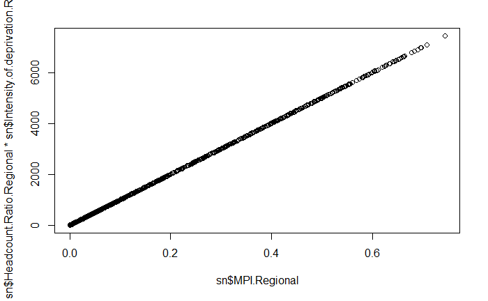

```r
plot(sn$MPI.Regional, sn$Headcount.Ratio.Regional * sn$Intensity.of.deprivation.Regional)
```

Hay una fuerte correlación entre los distintos elementos de ambas tablas porque básicamente son distintas derivaciones de un mismo calculo.

## Ruido

Hay multiples formas de buscar ruido. Una primera opción sería buscar variables cuyos boxplot marquen outliers. Es poco probable que los valores se encuentren a una distancia mayor de 3 rangos intercuartiles.

Una seguna es gráficar la distribución de una variable ordenada. De esta forma se puede mejor la continuidad de una variable y si hay valores que se alejan del sector donde se concentran la mayor parte de los registros.

```r
for (var in num_simple) {
  png(filename=paste("Plot-", var,"-.png"))

  plot(sort(no_na_df_simple[[var]]) , type = "p", col="red",
     ylab = "Headcount.Ratio.Regional", xlab = "Observaciones", main = "Dato original vs suavizado")
  dev.off()

  png(filename=paste("BoxPlot-", var,"-.png"))
  p2<-ggplot(no_na_df_simple, aes(x=no_na_df_simple[[var]])) +
    geom_boxplot() +
    coord_flip()
  plot(p2)
  dev.off()
}
```

## Discretizar

### Por frecuencia

Bin = 2

```r
bin_eq_freq <- discretize(no_na_df_simple$R.Urban,"equalfreq", 2)
bin_eq_freq$R.Urban = no_na_df_simple$R.Urban

# Por cada bin calculamos la media y reemplazamos en el atributo suavizado
for(bin in 1:2){
  bin_eq_freq$suavizado[ bin_eq_freq$X==bin] = mean(bin_eq_freq$R.Urban[ bin_eq_freq$X==bin])
}

# grafico Sepal.Width ordenado de menor a mayor
plot(sort(no_na_df_simple$R.Urban) , type = "p", col="red",
     ylab = "R.Urban", xlab = "Observaciones", main = "Dato original vs suavizado")
# Agrego la serie de la variable media
lines(sort(bin_eq_freq$suavizado),
      type = "p", col="blue")
```

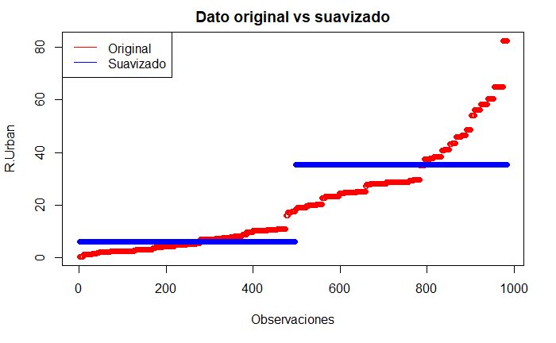

```r
legend("topleft", legend=c("Original", "Suavizado"), col=c("red", "blue"), lty=1)
```

Bin= 10

```r
bin_eq_freq <- discretize(no_na_df_simple$R.Urban,"equalfreq", 10)
bin_eq_freq$R.Urban = no_na_df_simple$R.Urban

# Por cada bin calculamos la media y reemplazamos en el atributo suavizado
for(bin in 1:10){
  bin_eq_freq$suavizado[ bin_eq_freq$X==bin] = mean(bin_eq_freq$R.Urban[ bin_eq_freq$X==bin])
}

# grafico Sepal.Width ordenado de menor a mayor
plot(sort(no_na_df_simple$R.Urban) , type = "p", col="red",
     ylab = "R.Urban", xlab = "Observaciones", main = "Dato original vs suavizado")
# Agrego la serie de la variable media
lines(sort(bin_eq_freq$suavizado),
      type = "p", col="blue")
```

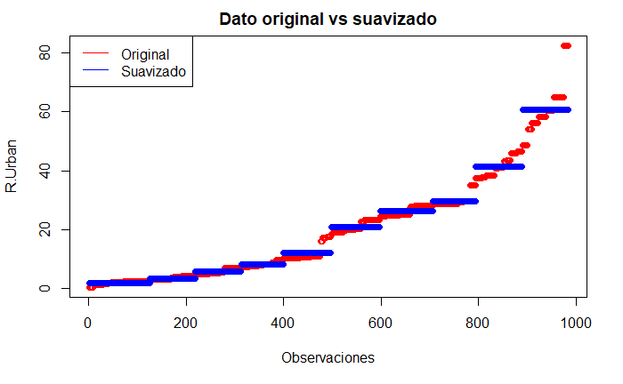

```r
legend("topleft", legend=c("Original", "Suavizado"), col=c("red", "blue"), lty=1)
```

Bin= 20

```r
bin_eq_freq <- discretize(no_na_df_simple$R.Urban,"equalfreq", 20)
bin_eq_freq$R.Urban = no_na_df_simple$R.Urban

# Por cada bin calculamos la media y reemplazamos en el atributo suavizado
for(bin in 1:20){
  bin_eq_freq$suavizado[ bin_eq_freq$X==bin] = mean(bin_eq_freq$R.Urban[ bin_eq_freq$X==bin])
}

# grafico Sepal.Width ordenado de menor a mayor
plot(sort(no_na_df_simple$R.Urban) , type = "p", col="red",
     ylab = "R.Urban", xlab = "Observaciones", main = "Dato original vs suavizado")
# Agrego la serie de la variable media
lines(sort(bin_eq_freq$suavizado),
      type = "p", col="blue")
```

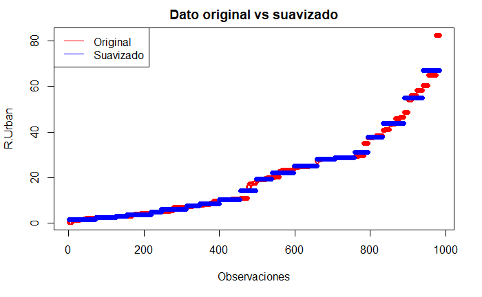

```r
legend("topleft", legend=c("Original", "Suavizado"), col=c("red", "blue"), lty=1)
```